# Data Manipulation_2

## Task: NYC Payroll

## Assignment Overview

In this Task, we will use payroll data downloaded from NYC Open Data to answer specific questions. These questions just scratch the surface of analysis possibilities.

```python
# common imports
import pandas as pd
import numpy as np
```

```python
# import data - use dtype argument due to large file size
nyc_full = pd.read_csv('NYC_Payroll_Data.csv', dtype={'Fiscal Year': 'int', 'Payroll Number': 'float', 'Agency Name': 'str',
                                                            'Last Name': 'str','First Name': 'str','Mid Init': 'str',
                                                            'Agency Start Date': 'str','Work Location Borough': 'str','Title Description': 'str',
                                                            'Leave Status as of June 30': 'str','Base Salary': 'float','Pay Basis': 'str',
                                                            'Regular Hours': 'float', 'Regular Gross Paid': 'float', 'OT Hours': 'float',
                                                            'Total OT Paid': 'float', 'Total Other Pay': 'float'})
```

```python
# make copy of data so you do not need to import again if you make a mistake and need to "reset"
nyc = nyc_full.copy()
```

```python
# check information about DataFrame
nyc.info()
```

```
<class 'pandas.core.frame.DataFrame'>
RangeIndex: 4496767 entries, 0 to 4496766
Data columns (total 17 columns):
 #   Column                      Dtype
---  ------                      -----
 0   Fiscal Year                 int32
 1   Payroll Number              float64
 2   Agency Name                 object
 3   Last Name                   object
 4   First Name                  object
 5   Mid Init                    object
 6   Agency Start Date           object
 7   Work Location Borough       object
 8   Title Description           object
 9   Leave Status as of June 30  object
 10  Base Salary                 float64
 11  Pay Basis                   object
 12  Regular Hours               float64
 13  Regular Gross Paid          float64
 14  OT Hours                    float64
 15  Total OT Paid               float64
 16  Total Other Pay             float64
dtypes: float64(7), int32(1), object(9)
memory usage: 566.1+ MB
```

```python
# check first five rows of data
nyc.head()
```

|  | Fiscal Year | Payroll Number | Agency Name | Last Name | First Name | Mid Init | Agency Start Date | Work Location Borough | Title Description | Leave Status as of June 30 | Base Salary | Pay Basis | Regular Hours | Regular Gross Paid | OT Hours | Total OT Paid | Total Other Pay |
| --- | --- | --- | --- | --- | --- | --- | --- | --- | --- | --- | --- | --- | --- | --- | --- | --- | --- |
| 0 | 2020 | 17.0 | OFFICE OF EMERGENCY MANAGEMENT | BEREZIN | MIKHAIL | NaN | 08/10/2015 | BROOKLYN | EMERGENCY PREPAREDNESS MANAGER | ACTIVE | 86005.0 | per Annum | 1820.0 | 84698.21 | 0.0 | 0.0 | 0.0 |
| 1 | 2020 | 17.0 | OFFICE OF EMERGENCY MANAGEMENT | GEAGER | VERONICA | M | 09/12/2016 | BROOKLYN | EMERGENCY PREPAREDNESS MANAGER | ACTIVE | 86005.0 | per Annum | 1820.0 | 84698.21 | 0.0 | 0.0 | 0.0 |
| 2 | 2020 | 17.0 | OFFICE OF EMERGENCY MANAGEMENT | RAMANI | SHRADDHA | NaN | 02/22/2016 | BROOKLYN | EMERGENCY PREPAREDNESS MANAGER | ACTIVE | 86005.0 | per Annum | 1820.0 | 84698.21 | 0.0 | 0.0 | 0.0 |
| 3 | 2020 | 17.0 | OFFICE OF EMERGENCY MANAGEMENT | ROTTA | JONATHAN | D | 09/16/2013 | BROOKLYN | EMERGENCY PREPAREDNESS MANAGER | ACTIVE | 86005.0 | per Annum | 1820.0 | 84698.21 | 0.0 | 0.0 | 0.0 |
| 4 | 2020 | 17.0 | OFFICE OF EMERGENCY MANAGEMENT | WILSON II | ROBERT | P | 04/30/2018 | BROOKLYN | EMERGENCY PREPAREDNESS MANAGER | ACTIVE | 86005.0 | per Annum | 1820.0 | 84698.21 | 0.0 | 0.0 | 0.0 |

If you were to research the values in the DataFrame further, you will notice that there are some values in lowercase and most are listed in all uppercase. Because of this, run the function below that will transform all characters to uppercase to be consistent with the majority of the data.

```python
# run this code block
def upper_case(df):
    '''
    Takes as input the `nyc` DataFrame.
    Then capitlizes each character in columns with "object" data type.
    '''
    # iterating over each column in the DataFrame
    for col in df.columns:
        # checking datatype of each column
        if df[col].dtype == 'object':
            # applying upper function on column
            df[col] = df[col].str.upper()

upper_case(nyc)
```

**Q1:** How many rows are contained in the full dataset?

```python
rows = nyc.shape[0]
print("Number of Rows = ", rows)
```

```
Number of Rows =  4496767
```

**Q2:** How many individuals are represented using only the 2021 fiscal year data?

```python
### ENTER CODE HERE ###
nyc2 = nyc.copy()
nyc2 = nyc2[nyc2['Fiscal Year']==2021]
print("Individuals represented = ",nyc2.shape[0])
```

```
Individuals represented =  573477
```

**Q3:** Who had the highest base salary in 2021? What was his/her base salary? What Agency did he/she work for? What was his/her title?

```python
### ENTER CODE HERE ###
highest_salary = nyc2['Base Salary'].max()
print("Highest Salary = ",highest_salary)
```

```
Highest Salary =  414707.0
```

**Q4:** List the top 5 employees with the highest regular gross pay in 2021.

```python
### ENTER CODE HERE ###
top_5 = nyc2.sort_values(by = 'Regular Gross Paid',ascending = False)
top_5 = nyc2.head()
top_5
```

|  | Fiscal Year | Payroll Number | Agency Name | Last Name | First Name | Mid Init | Agency Start Date | Work Location Borough | Title Description | Leave Status as of June 30 | Base Salary | Pay Basis | Regular Hours | Regular Gross Paid | OT Hours | Total OT Paid | Total Other Pay |
| --- | --- | --- | --- | --- | --- | --- | --- | --- | --- | --- | --- | --- | --- | --- | --- | --- | --- |
| 3923290 | 2021 | 996.0 | NYC HOUSING AUTHORITY | MUSTACIUOLO | VITO | J | 02/26/2018 | MANHATTAN | EXECUTIVE DIRECTOR | ACTIVE | 258000.0 | PER ANNUM | 1820.0 | 257260.30 | 0.00 | 0.00 | 258000.00 |
| 3923291 | 2021 | 996.0 | NYC HOUSING AUTHORITY | RUSS | GREGORY | P | 08/12/2019 | MANHATTAN | CHAIR | ACTIVE | 414707.0 | PER ANNUM | 1820.0 | 413518.05 | 0.00 | 0.00 | 500.00 |
| 3923292 | 2021 | 816.0 | DEPT OF HEALTH/MENTAL HYGIENE | MCGROARTY | MICHAEL | NaN | 10/06/2014 | QUEENS | STATIONARY ENGINEER | ACTIVE | 508.8 | PER DAY | 2080.0 | 132288.00 | 2374.75 | 238829.13 | 40105.00 |
| 3923293 | 2021 | 816.0 | DEPT OF HEALTH/MENTAL HYGIENE | HALLAHAN | PATRICK | M | 02/26/2018 | BROOKLYN | STATIONARY ENGINEER | ACTIVE | 508.8 | PER DAY | 2080.0 | 132288.00 | 2115.25 | 218628.18 | 56616.07 |
| 3923294 | 2021 | 816.0 | DEPT OF HEALTH/MENTAL HYGIENE | PETTIT | PATRICK | J | 08/02/2010 | MANHATTAN | STATIONARY ENGINEER | ACTIVE | 508.8 | PER DAY | 2080.0 | 132288.00 | 2152.75 | 218694.96 | 38611.82 |

**Q5:** Which employee had the highest total OT paid in 2021?

```python
### ENTER CODE HERE ###
highest_OT  =  (nyc2[nyc2['Total OT Paid'] == nyc2['Total OT Paid'].max()])
highest_OT
```

|  | Fiscal Year | Payroll Number | Agency Name | Last Name | First Name | Mid Init | Agency Start Date | Work Location Borough | Title Description | Leave Status as of June 30 | Base Salary | Pay Basis | Regular Hours | Regular Gross Paid | OT Hours | Total OT Paid | Total Other Pay |
| --- | --- | --- | --- | --- | --- | --- | --- | --- | --- | --- | --- | --- | --- | --- | --- | --- | --- |
| 3923298 | 2021 | 996.0 | NYC HOUSING AUTHORITY | PROCIDA | ROBERT | NaN | 04/13/1987 | BRONX | SUPERVISOR PLUMBER | ACTIVE | 387.03 | PER DAY | 1820.0 | 100627.8 | 2249.5 | 248749.72 | 7215.34 |

**Q6:** Which employee that was still active as of June 30th had the highest total other pay in 2021?

```python
### ENTER CODE HERE ###
highest_otherpay  =  (nyc2[nyc2['Leave Status as of June 30'] == 'ACTIVE'])
highest_otherpay  =  (highest_otherpay[highest_otherpay['Total Other Pay'] == highest_otherpay['Total Other Pay'].max()])
highest_otherpay
```

|  | Fiscal Year | Payroll Number | Agency Name | Last Name | First Name | Mid Init | Agency Start Date | Work Location Borough | Title Description | Leave Status as of June 30 | Base Salary | Pay Basis | Regular Hours | Regular Gross Paid | OT Hours | Total OT Paid | Total Other Pay |
| --- | --- | --- | --- | --- | --- | --- | --- | --- | --- | --- | --- | --- | --- | --- | --- | --- | --- |
| 3923290 | 2021 | 996.0 | NYC HOUSING AUTHORITY | MUSTACIUOLO | VITO | J | 02/26/2018 | MANHATTAN | EXECUTIVE DIRECTOR | ACTIVE | 258000.0 | PER ANNUM | 1820.0 | 257260.3 | 0.0 | 0.0 | 258000.0 |

**Q7:** According to the Data Dictionary, an employee's total gross pay is equal to the sum of their regular gross pay, total overtime pay, and total other pay. Create a column called `Total Gross Paid` in the `nyc` DataFrame that sums those three respective pay columns for each employee.

Which 10 individuals had the highest total gross pay in 2021?

```python
### ENTER CODE HERE ###
nyc2['Total Gross Paid'] = nyc2['Regular Gross Paid']+nyc2['Total OT Paid']+nyc2['Total Other Pay']
top_10_gross = nyc2.sort_values(by = 'Regular Gross Paid',ascending = False)
top_10_gross = nyc2.head(10)
top_10_gross
```

|  | Fiscal Year | Payroll Number | Agency Name | Last Name | First Name | Mid Init | Agency Start Date | Work Location Borough | Title Description | Leave Status as of June 30 | Base Salary | Pay Basis | Regular Hours | Regular Gross Paid | OT Hours | Total OT Paid | Total Other Pay | Total Gross Paid |
| --- | --- | --- | --- | --- | --- | --- | --- | --- | --- | --- | --- | --- | --- | --- | --- | --- | --- | --- |
| 3923290 | 2021 | 996.0 | NYC HOUSING AUTHORITY | MUSTACIUOLO | VITO | J | 02/26/2018 | MANHATTAN | EXECUTIVE DIRECTOR | ACTIVE | 258000.00 | PER ANNUM | 1820.0 | 257260.30 | 0.00 | 0.00 | 258000.00 | 515260.30 |
| 3923291 | 2021 | 996.0 | NYC HOUSING AUTHORITY | RUSS | GREGORY | P | 08/12/2019 | MANHATTAN | CHAIR | ACTIVE | 414707.00 | PER ANNUM | 1820.0 | 413518.05 | 0.00 | 0.00 | 500.00 | 414018.05 |
| 3923292 | 2021 | 816.0 | DEPT OF HEALTH/MENTAL HYGIENE | MCGROARTY | MICHAEL | NaN | 10/06/2014 | QUEENS | STATIONARY ENGINEER | ACTIVE | 508.80 | PER DAY | 2080.0 | 132288.00 | 2374.75 | 238829.13 | 40105.00 | 411222.13 |
| 3923293 | 2021 | 816.0 | DEPT OF HEALTH/MENTAL HYGIENE | HALLAHAN | PATRICK | M | 02/26/2018 | BROOKLYN | STATIONARY ENGINEER | ACTIVE | 508.80 | PER DAY | 2080.0 | 132288.00 | 2115.25 | 218628.18 | 56616.07 | 407532.25 |
| 3923294 | 2021 | 816.0 | DEPT OF HEALTH/MENTAL HYGIENE | PETTIT | PATRICK | J | 08/02/2010 | MANHATTAN | STATIONARY ENGINEER | ACTIVE | 508.80 | PER DAY | 2080.0 | 132288.00 | 2152.75 | 218694.96 | 38611.82 | 389594.78 |
| 3923295 | 2021 | 816.0 | DEPT OF HEALTH/MENTAL HYGIENE | TELEHANY | STEPHEN | M | 01/16/2007 | QUEENS | STATIONARY ENGINEER | ACTIVE | 508.80 | PER DAY | 2080.0 | 132288.00 | 1876.25 | 192296.19 | 51160.20 | 375744.39 |
| 3923296 | 2021 | 462.0 | GUTTMAN COMMUNITY COLLEGE | EVENBECK | SCOTT | E | 04/17/2011 | MANHATTAN | PRESIDENT | CEASED | 228000.00 | PER ANNUM | 980.0 | 122427.81 | 0.00 | 0.00 | 244495.20 | 366923.01 |
| 3923297 | 2021 | 56.0 | POLICE DEPARTMENT | NaN | NaN | NaN | 07/16/1984 | MANHATTAN | CAPTAIN DETAILED AS CHIEF OF TRAINING | CEASED | 241116.00 | PER ANNUM | 400.0 | 46222.47 | 0.00 | 0.00 | 312126.91 | 358349.38 |
| 3923298 | 2021 | 996.0 | NYC HOUSING AUTHORITY | PROCIDA | ROBERT | NaN | 04/13/1987 | BRONX | SUPERVISOR PLUMBER | ACTIVE | 387.03 | PER DAY | 1820.0 | 100627.80 | 2249.50 | 248749.72 | 7215.34 | 356592.86 |
| 3923299 | 2021 | 15.0 | OFFICE OF THE COMPTROLLER | DONE | ALEXIS | NaN | 03/12/2012 | MANHATTAN | PENSION INVESTMENT ADVISOR | ACTIVE | 350000.00 | PER ANNUM | 1820.0 | 349014.96 | 0.00 | 0.00 | 0.00 | 349014.96 |

**Q8:** What is the average, median, and standard deviation for total gross pay for all individuals in 2021?

```python
### ENTER CODE HERE ###
total_gross_pay = nyc2['Total Gross Paid']
print(f'average,: {total_gross_pay.mean()}')
print(f'median: {total_gross_pay.median()}')
print(f'standard deviation: {total_gross_pay.std()}')
```

```
average,: 52017.993508579806
median: 43359.15
standard deviation: 50730.46191268696
```

**Q9:** How many different agencies are represented in the 2021 data? What are the names of the agencies?

```python
### ENTER CODE HERE ###
print(nyc2['Agency Name'].nunique())
print(nyc2['Agency Name'].unique())
```

```
156
['NYC HOUSING AUTHORITY' 'DEPT OF HEALTH/MENTAL HYGIENE'
 'GUTTMAN COMMUNITY COLLEGE' 'POLICE DEPARTMENT'
 'OFFICE OF THE COMPTROLLER' 'BOARD OF ELECTION'
 "ADMIN FOR CHILDREN'S SVCS" 'DEPARTMENT OF CORRECTION'
 'DEPT OF CITYWIDE ADMIN SVCS' 'DEPT OF ENVIRONMENT PROTECTION'
 'OFFICE OF THE ACTUARY' 'DEPARTMENT OF FINANCE'
 'DEPARTMENT OF SANITATION' 'COMMUNITY COLLEGE (QUEENSBORO)'
 'FIRE DEPARTMENT' 'DEPT OF ED PEDAGOGICAL' 'OFFICE OF THE MAYOR'
 'COMMUNITY COLLEGE (BRONX)' 'COMMUNITY COLLEGE (KINGSBORO)'
 'COMMUNITY COLLEGE (LAGUARDIA)' 'COMMUNITY COLLEGE (MANHATTAN)'
 'DISTRICT ATTORNEY-MANHATTAN' 'CAMPAIGN FINANCE BOARD'
 'COMMUNITY COLLEGE (HOSTOS)' 'DEPT OF PARKS & RECREATION'
 'DEPARTMENT OF EDUCATION ADMIN' 'DEPARTMENT OF TRANSPORTATION'
 'CITY COUNCIL' 'HRA/DEPT OF SOCIAL SERVICES' 'TEACHERS RETIREMENT SYSTEM'
 'TAXI & LIMOUSINE COMMISSION' 'NYC EMPLOYEES RETIREMENT SYS'
 'HOUSING PRESERVATION & DVLPMNT' 'DEPT. OF HOMELESS SERVICES'
 'DEPARTMENT OF CITY PLANNING' 'OFFICE OF COLLECTIVE BARGAININ'
 'BUSINESS INTEGRITY COMMISSION' 'LAW DEPARTMENT'
 'FINANCIAL INFO SVCS AGENCY' 'OFFICE OF LABOR RELATIONS'
 'DEPARTMENT OF BUILDINGS' 'DEPT OF INFO TECH & TELECOMM' 'CITY CLERK'
 'DEPARTMENT FOR THE AGING' 'NYC POLICE PENSION FUND'
 'OFF OF PAYROLL ADMINISTRATION' 'OFFICE OF MANAGEMENT & BUDGET'
 'DEPARTMENT OF INVESTIGATION' 'BRONX DISTRICT ATTORNEY'
 'HUMAN RIGHTS COMMISSION' 'DEPARTMENT OF PROBATION'
 'DEPARTMENT OF BUSINESS SERV.' 'TAX COMMISSION'
 'MAYORS OFFICE OF CONTRACT SVCS' 'CULTURAL AFFAIRS'
 'NYC FIRE PENSION FUND' 'DEPT OF YOUTH & COMM DEV SRVS'
 'ADMIN TRIALS AND HEARINGS' "NYC DEPT OF VETERANS' SERVICES"
 'CIVILIAN COMPLAINT REVIEW BD' 'DISTRICT ATTORNEY KINGS COUNTY'
 'INDEPENDENT BUDGET OFFICE' 'CONFLICTS OF INTEREST BOARD'
 'BOROUGH PRESIDENT-BRONX' 'DEPT. OF DESIGN & CONSTRUCTION'
 'LANDMARKS PRESERVATION COMM' 'DISTRICT ATTORNEY RICHMOND COU'
 'DISTRICT ATTORNEY-SPECIAL NARC' 'DISTRICT ATTORNEY QNS COUNTY'
 'DEPT OF RECORDS & INFO SERVICE' 'CONSUMER AFFAIRS'
 'OFFICE OF EMERGENCY MANAGEMENT' 'BOARD OF CORRECTION'
 'HUNTER COLLEGE HIGH SCHOOL' 'PUBLIC ADMINISTRATOR-NEW YORK'
 'PUBLIC ADMINISTRATOR-BRONX' 'PUBLIC ADMINISTRATOR-KINGS'
 'PUBLIC ADMINISTRATOR-QUEENS' 'PUBLIC ADMINISTRATOR-RICHMOND'
 'PUBLIC ADVOCATE' 'MUNICIPAL WATER FIN AUTHORITY' 'DOE CUSTODIAL PAYROL'
```

[output cut: 22 more lines]

```
 'MANHATTAN COMMUNITY BOARD #6' 'BRONX COMMUNITY BOARD #11'
 'BROOKLYN COMMUNITY BOARD #13' 'QUEENS COMMUNITY BOARD #7'
 'BROOKLYN COMMUNITY BOARD #3' 'MANHATTAN COMMUNITY BOARD #3'
 'BROOKLYN COMMUNITY BOARD #6' 'MANHATTAN COMMUNITY BOARD #2'
 'MANHATTAN COMMUNITY BOARD #1' 'BRONX COMMUNITY BOARD #8'
 'MANHATTAN COMMUNITY BOARD #8' 'DEPT OF ED PARA PROFESSIONALS'
 'BROOKLYN COMMUNITY BOARD #17' 'MANHATTAN COMMUNITY BOARD #10'
 'QUEENS COMMUNITY BOARD #11' 'MANHATTAN COMMUNITY BOARD #7'
 'BRONX COMMUNITY BOARD #10' 'BROOKLYN COMMUNITY BOARD #4'
 'BROOKLYN COMMUNITY BOARD #9' 'BRONX COMMUNITY BOARD #5'
 'QUEENS COMMUNITY BOARD #9' 'DEPT OF ED HRLY SUPPORT STAFF'
 'MANHATTAN COMMUNITY BOARD #5' 'BRONX COMMUNITY BOARD #7'
 'BROOKLYN COMMUNITY BOARD #15' 'BROOKLYN COMMUNITY BOARD #2'
 'BOARD OF ELECTION POLL WORKERS' 'PERSONNEL MONITORS'
 'PUBLIC SERVICE CORPS' 'DEPARTMENT OF JUVENILE JUSTICE']
```

**Q10:** What agencies had the highest and lowest median total gross pay in 2021?

```python
### ENTER CODE HERE ###
agencies = nyc2.groupby('Agency Name')['Total Gross Paid'].median()
max_agency  = agencies[agencies == agencies.max()]
#print("Max:", max_agency)
#print("Min: ",agencies[agencies == agencies.min()])
```

[output not shown]

**Q11:** How much did Mayor Bill de Blasio make in 2021 (total gross pay)? Who had the highest total gross pay in the Mayor's office? When was Mayor Bill de Blasio's start date in the Mayor's office?

```python
### ENTER CODE HERE ###
mayor_bill = (nyc2[nyc2['First Name'] == 'BILL'])
mayor_bill = (mayor_bill[mayor_bill['Last Name'] == 'DE BLASIO'])
mayor_bill_gross = mayor_bill['Total Gross Paid'].sum()
mayor_bill_startdate = mayor_bill['Agency Start Date'].sum()
print("Mayor Bill Start Date: ",mayor_bill_startdate)
print("Mayor Bill Gross Pay: ",mayor_bill_gross)
mayor_office = (nyc2[nyc2['Agency Name'] == 'OFFICE OF THE MAYOR'])
mayor_office = mayor_office[mayor_office['Total Gross Paid'] == mayor_office['Total Gross Paid'].max()]
print("Higest Gross Pay in Mayors office:", mayor_office['First Name'].max(), mayor_office['Last Name'].max())
```

```
Mayor Bill Start Date:  01/01/2014
Mayor Bill Gross Pay:  253064.89
Higest Gross Pay in Mayors office: DEAN FULEIHAN
```

**Q12:** How much was the total cumulative gross pay for all NYC employees in 2021? Total cumulative OT pay? What was the percentage of overtime pay as compared to total gross pay for all data in 2021?

```python
### ENTER CODE HERE ###
total_cumulative_gross_pay = nyc2['Total Gross Paid'].sum()
total_cumulative_OT_pay = nyc2['Total OT Paid'].sum()
percentage = total_cumulative_OT_pay/total_cumulative_gross_pay*100
print(total_cumulative_gross_pay)
print(total_cumulative_OT_pay)
print(percentage)
```

```
29831122863.320004
1796557247.7300003
6.022425826749639
```

**Q13:** What was the average base salary per work location in 2021?

```python
### ENTER CODE HERE ###
avg_salary_location = nyc2.groupby('Work Location Borough')['Base Salary'].mean().sort_values(ascending = False)
avg_salary_location
```

```
Work Location Borough
WASHINGTON DC    133559.666667
OTHER            120124.578298
ALBANY            91296.344000
ULSTER            79805.588939
GREENE            72366.213333
SULLIVAN          72212.089297
SCHOHARIE         70127.428571
WESTCHESTER       68429.795154
DELAWARE          65365.190366
PUTNAM            63959.932895
DUTCHESS          60963.991379
BROOKLYN          59288.815687
QUEENS            58846.691720
RICHMOND          58241.712893
ORANGE            57403.000000
BRONX             55290.460386
MANHATTAN         43044.492124
NASSAU            29930.476500
Name: Base Salary, dtype: float64
```

**Q14:** For the work location that has the highest average base salary above, which individual in that location makes the highest base salary?

```python
### ENTER CODE HERE ###
highest_base_salary_location = nyc2[nyc2['Work Location Borough'] == 'WASHINGTON DC']
highest_base_salary_location = highest_base_salary_location[highest_base_salary_location['Base Salary'] ==  highest_base_salary_location['Base Salary'].max()]
print(highest_base_salary_location['First Name'].max(),highest_base_salary_location['Last Name'].max())
```

```
REBECCA KAGAN STERNHELL
```

**Q15:** Group the 2021 data by work location and then agency name. What are the five largest median base salaries from that grouped data?

```python
### ENTER CODE HERE ###
grouped_location_agency = nyc2.groupby(['Work Location Borough','Agency Name'])['Base Salary'].median().sort_values(ascending = False)
grouped_location_agency.head()
```

```
Work Location Borough  Agency Name
WASHINGTON DC          DEPT OF INFO TECH & TELECOMM     177904.0
BRONX                  DEPT OF INFO TECH & TELECOMM     147213.0
                       COMMUNITY COLLEGE (LAGUARDIA)    147000.0
WASHINGTON DC          LAW DEPARTMENT                   142057.0
ALBANY                 OFFICE OF THE MAYOR              130000.0
Name: Base Salary, dtype: float64
```

**Q16:** How has the cumulative total gross pay for all individuals changed over time? Be prepared to answer just basic questions such as has it mostly increased or decreased, what year had the highest total gross pay, etc.

```python
### ENTER CODE HERE ###
nyc['Total Gross Paid'] = nyc['Regular Gross Paid']+nyc['Total OT Paid']+nyc['Total Other Pay']
nyc.groupby(['Fiscal Year'])['Total Gross Paid'].sum()
```

```
Fiscal Year
2014    2.286248e+10
2015    2.433409e+10
2016    2.551812e+10
2017    2.714594e+10
2018    2.754932e+10
2019    2.951697e+10
2020    3.041857e+10
2021    2.983112e+10
Name: Total Gross Paid, dtype: float64
```

Ans: Mostly Increased and year 2020 had the highest total gross pay

**Q17:** How has the total number of employees for each fiscal year changed over time? Again, be prepared to answer just some basic questions.

```python
### ENTER CODE HERE ###
nyc.groupby(['Fiscal Year'])['First Name'].count()
```

```
Fiscal Year
2014    509387
2015    577636
2016    544508
2017    562005
2018    545798
2019    592048
2020    589835
2021    568889
Name: First Name, dtype: int64
```

Ans: Number of employees have varied overtime but there is a overall increase in number of employees from 2014 to 2021

**Q18:** Who are the 2 top base salary employees per work location borough for 2021? You may want to think about creating a custom function to make this easier to answer.

```python
### ENTER CODE HERE ###
top_base = nyc2.groupby(['Work Location Borough','First Name','Last Name'])['Base Salary'].max().sort_values(ascending = False)
top_base.groupby(level=0).head(2)
```

```
Work Location Borough  First Name  Last Name
MANHATTAN              GREGORY     RUSS               414707.0
                       MEISHA      ROSS PORTER        363346.0
QUEENS                 CHRISTINE   MANGINO            270000.0
                       KENNETH     ADAMS              270000.0
BRONX                  DAISY       DE FILIPPIS        260000.0
BROOKLYN               JOHN        SCRIVANI           243171.0
                       DANIEL      NIGRO              243171.0
OTHER                  DONALD      CONYERS            241102.0
RICHMOND               FRANK       VEGA               240511.0
BRONX                  KENNETH     LEHR               240511.0
RICHMOND               KEVIN       WOODS              235462.0
SULLIVAN               PAUL        RUSH               231796.0
OTHER                  LAURA       FEIJOO             225666.0
ALBANY                 SIMONIA     BROWN              203996.0
SULLIVAN               SEAN        MCANDREW           195694.0
WESTCHESTER            DAVID       WARNE              195295.0
                       ADAM        REAVES             191752.0
ULSTER                 STEVEN      SCHINDLER          188100.0
DELAWARE               JOHN        VICKERS            188099.0
WASHINGTON DC          REBECCA     KAGAN STERNHELL    178190.0
                       MAX         SEVILLIA           177904.0
ULSTER                 LORI        EMERY              177507.0
DUTCHESS               GEORGE      SCHMITT            170804.0
                       FRANK       MILAZZO            166507.0
ALBANY                 ARIANA      CAPLAN             161136.0
SCHOHARIE              BRIAN       HANDY              150393.0
GREENE                 LARRY       ARNOLD             137534.0
DELAWARE               ROBERT      FLYNN III          134280.0
PUTNAM                 JAMES       KEESLER            126624.0
SCHOHARIE              EMORY       CHASE              112561.0
PUTNAM                 PATRICK     FRAWLEY             91648.0
GREENE                 JOSHUA      JONES               91551.0
NASSAU                 LUANNE      HORNE               81186.0
                       LORETTA     CONROY              81186.0
ORANGE                 ESTER       CROSS               57403.0
Name: Base Salary, dtype: float64
```

**Q19:** Who are the 2 top total gross paid employees per borough for 2021? If you made a custom function for the previous question, this will be much easier to answer.

```python
### ENTER CODE HERE ###
top_gross = nyc2.groupby(['Work Location Borough','First Name','Last Name'])['Total Gross Paid'].max().sort_values(ascending = False)
top_gross.groupby(level=0).head(2)
```

```
Work Location Borough  First Name   Last Name
MANHATTAN              VITO         MUSTACIUOLO        515260.30
                       GREGORY      RUSS               414018.05
QUEENS                 MICHAEL      MCGROARTY          411222.13
BROOKLYN               PATRICK      HALLAHAN           407532.25
QUEENS                 STEPHEN      TELEHANY           375744.39
BRONX                  ROBERT       PROCIDA            356592.86
                       GARFIELD     DALEY              347824.78
BROOKLYN               CHRISTOPHER  REINHOLD           347654.07
RICHMOND               JOSEPH       ALBANESE           276537.47
                       WILLIAM      HORAN              264396.65
OTHER                  DANIEL       SCANLON            263786.62
                       JOAN         INDART ETIENNE     247171.40
SULLIVAN               PAUL         RUSH               226703.15
WESTCHESTER            DANIEL       MASSI              200973.04
                       RICHARD      VENTURA            199641.63
SULLIVAN               SEAN         MCANDREW           191479.22
DELAWARE               JOHN         VICKERS            184966.23
DUTCHESS               CHARLES      NEWMAN             182907.46
ALBANY                 SIMONIA      BROWN              179952.18
WASHINGTON DC          REBECCA      KAGAN STERNHELL    174429.45
ULSTER                 JOSEPH       ZIBELLA            169345.53
                       TODD         WEST               168101.51
DUTCHESS               WESTON       VANVORST           165782.71
SCHOHARIE              BRIAN        HANDY              148088.64
GREENE                 ERNEST       FANKHAUSER         143733.71
ALBANY                 MARK         FAHD               140780.85
WASHINGTON DC          KIMBERLY     CONWAY             139480.01
DELAWARE               ROBERT       BIANCHI            137612.58
PUTNAM                 WILLIAM      CRUGER             133032.34
                       JAMES        KEESLER            126810.39
SCHOHARIE              EMORY        CHASE              125288.56
GREENE                 JOSHUA       JONES              114065.93
NASSAU                 SUSAN        DEELY              102972.26
                       LORETTA      CONROY              98429.10
ORANGE                 ESTER        CROSS               63313.06
Name: Total Gross Paid, dtype: float64
```

**Q20:** For 2021, what percentage of individuals earned income per annum, per day and per hour?

```python
total = nyc2['Pay Basis'].count()
per_annum = nyc2[nyc2['Pay Basis'] == 'PER ANNUM']
per_annum = per_annum['Pay Basis'].count()
per_day = nyc2[nyc2['Pay Basis'] == 'PER DAY']
per_day = per_day['Pay Basis'].count()
per_hour = nyc2[nyc2['Pay Basis'] == 'PER HOUR']
per_hour = per_hour['Pay Basis'].count()
percentage_annum = per_annum/total*100
percentage_day = per_day/total*100
percentage_hour = per_hour/total*100
print('Percentages',percentage_annum,percentage_day,percentage_hour)
```

```
Percentages 59.96718264202401 24.03409378231385 15.675606868278939
```

**Q21:** What is the average total gross pay broken down by the categories in the `Pay Basis` column for 2021?

```python
### ENTER CODE HERE ###
avg_gross_pay_basis = nyc2.groupby('Pay Basis')['Total Gross Paid'].mean()
avg_gross_pay_basis
```

```
Pay Basis
PER ANNUM          78625.133331
PER DAY            12462.578868
PER HOUR           11223.010701
PRORATED ANNUAL    35334.994949
Name: Total Gross Paid, dtype: float64
```

**Q22:** Create a pivot table using the median of total gross pay with the index by agency name and columns broken down by pay basis category. Include `margins=True`. Be prepared to answer questions based on this pivot table.

```python
### ENTER CODE HERE ###
output = pd.pivot_table(data=nyc,
                        index=['Agency Name'],
                        columns=['Pay Basis'],
                        values='Total Gross Paid',
                        aggfunc='median',
                        margins=True)
output
```

| Pay Basis Agency Name | PER ANNUM | PER DAY | PER HOUR | PRORATED ANNUAL | All |
| --- | --- | --- | --- | --- | --- |
| ADMIN FOR CHILDREN'S SVCS | 63820.190 | 115830.580 | 5492.295 | NaN | 63663.890 |
| ADMIN TRIALS AND HEARINGS | 55490.500 | 65795.105 | 28201.850 | NaN | 37206.710 |
| BOARD OF CORRECTION | 66263.995 | NaN | NaN | NaN | 66263.995 |
| BOARD OF CORRECTIONS | 60042.470 | NaN | NaN | NaN | 60042.470 |
| BOARD OF ELECTION | 55180.300 | NaN | 14585.030 | NaN | 37035.145 |
| ... | ... | ... | ... | ... | ... |
| STATEN ISLAND COMMUNITY BD #3 | 64494.630 | NaN | NaN | NaN | 64494.630 |
| TAX COMMISSION | 100457.425 | NaN | 13157.480 | 25604.700 | 78020.330 |
| TAXI & LIMOUSINE COMMISSION | 48566.750 | 65981.310 | 30615.490 | NaN | 46040.220 |
| TEACHERS RETIREMENT SYSTEM | 70234.065 | NaN | 3257.500 | NaN | 66221.770 |
| All | 69194.880 | 2807.200 | 1553.000 | 30810.245 | 39110.450 |

165 rows × 5 columns

**Q23:** What positions (grouped by titles) pay the most based on the median total gross pay in 2021? Show the top 10.

```python
### ENTER CODE HERE ###
nyc2.groupby('Title Description')['Total Gross Paid'].median().sort_values(ascending=False).head(10)
```

```
Title Description
PENSION INVESTMENT ADVISOR                      349014.960
CHAIR                                           326110.630
CHIEF ACTUARY                                   305032.320
CAPTAIN DETAILED AS CHIEF OF TRAINING           297703.365
FIRST DEPUTY MAYOR                              284742.280
PRESIDENT                                       275457.880
DIRECTOR OF  INVESTMENTS                        264254.050
CAPTAIN DETAILED AS CHIEF OF RISK MANAGEMENT    254051.460
MAYOR                                           253064.890
CHANCELLOR                                      251872.840
Name: Total Gross Paid, dtype: float64
```

**Q24:** Create a set of boxplots that show the total gross pay for all the employees of each of the various work location boroughs. In other words, your x axis will be the work locations and your y axis will be the total gross pay for the respective work location.

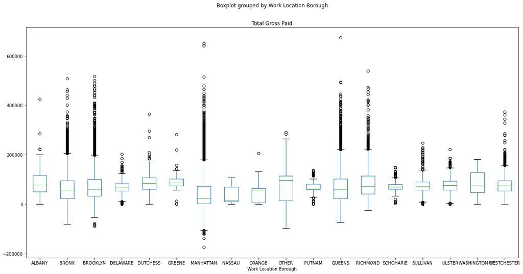

```python
### ENTER CODE HERE ###
nyc.boxplot(by ='Work Location Borough', column =['Total Gross Paid'], grid = False, figsize=(20, 10))
```

**Q25:** What are the top 10 agencies that have the most total number of overtime hours for 2021? What are the top 10 agencies that have the highest average number of overtime hours?

```python
### ENTER CODE HERE ###
nyc2.groupby('Agency Name')['OT Hours'].sum().sort_values(ascending=False).head(10)
```

```
Agency Name
POLICE DEPARTMENT                 10815884.93
FIRE DEPARTMENT                    8220712.59
DEPARTMENT OF SANITATION           4206474.56
DEPARTMENT OF CORRECTION           3323294.05
NYC HOUSING AUTHORITY              2686245.50
HRA/DEPT OF SOCIAL SERVICES        1276660.51
DEPARTMENT OF TRANSPORTATION       1074099.24
DEPT OF HEALTH/MENTAL HYGIENE       867652.73
DEPT OF ENVIRONMENT PROTECTION      679410.40
ADMIN FOR CHILDREN'S SVCS           539092.21
Name: OT Hours, dtype: float64
```

```python
nyc2.groupby('Agency Name')['OT Hours'].mean().sort_values(ascending=False).head(10)
```

```
Agency Name
BOARD OF ELECTION                454.591618
FIRE DEPARTMENT                  431.556123
DEPARTMENT OF SANITATION         347.556355
DEPARTMENT OF CORRECTION         265.184651
DEPT. OF HOMELESS SERVICES       195.478552
NYC HOUSING AUTHORITY            186.973307
POLICE DEPARTMENT                183.292124
DEPT OF CITYWIDE ADMIN SVCS      176.666722
DEPARTMENT OF TRANSPORTATION     172.379913
DEPT OF HEALTH/MENTAL HYGIENE    111.984090
Name: OT Hours, dtype: float64
```

**Q26:** Attempt to do this in one line of code by using `agg`. For the 2021 data, groupby the agency name and get the mean for the base salary, the median for the total overtime paid, and the standard deviation for the total gross paid. Save this as an object and be prepared to index it.

```python
nyc2.groupby('Agency Name').agg({'Base Salary': 'mean', 'Total OT Paid': 'median', 'Total Gross Paid' : 'std'})
```

| Agency Name | Base Salary | Total OT Paid | Total Gross Paid |
| --- | --- | --- | --- |
| ADMIN FOR CHILDREN'S SVCS | 68928.295008 | 21.95 | 32124.442208 |
| ADMIN TRIALS AND HEARINGS | 42774.316154 | 0.00 | 38677.473864 |
| BOARD OF CORRECTION | 94507.127586 | 0.00 | 41924.536647 |
| BOARD OF ELECTION | 41241.893459 | 13800.16 | 40142.716389 |
| BOARD OF ELECTION POLL WORKERS | 1.009790 | 0.00 | 2131.199265 |
| ... | ... | ... | ... |
| STATEN ISLAND COMMUNITY BD #2 | 54442.350000 | 0.00 | 60292.117307 |
| STATEN ISLAND COMMUNITY BD #3 | 76387.000000 | 0.00 | 23567.010355 |
| TAX COMMISSION | 88848.096129 | 0.00 | 51740.416321 |
| TAXI & LIMOUSINE COMMISSION | 59062.593797 | 0.08 | 30097.186297 |
| TEACHERS RETIREMENT SYSTEM | 80132.776992 | 0.00 | 48630.019747 |

156 rows × 3 columns

**Q27:** What is the average base salary for anyone with `DATABASE` in their title description for 2021?

```python
avg_sal_database = nyc2[nyc2['Title Description'].str.contains("DATABASE", na = False)]
avg_sal_database['Base Salary'].mean()
```

```
121565.0
```

**Q28:** Select only the 2021 individuals that get paid on a `per Annum` basis. Create a Series so that for each Agency, you calculate the range of the highest base salary for that agency minus the lowest base salary for that agency. Be prepared to index into this Series to answer questions.

Hint: I created a custom function similar to what we did in the "Data Aggregation and Grouping using Flags Data" module example.

```python
### ENTER CODE HERE ###
per_annum_employees = nyc2[nyc2['Pay Basis'] == 'PER ANNUM']
output = per_annum_employees.groupby(['Agency Name','First Name','Last Name'])['Base Salary'].max()
```

```python
output.groupby(level=0).max() - output.groupby(level=0).min()
```

```
Agency Name
ADMIN FOR CHILDREN'S SVCS        210651.0
ADMIN TRIALS AND HEARINGS        198426.0
BOARD OF CORRECTION              149900.0
BOARD OF ELECTION                204388.0
BOROUGH PRESIDENT-BRONX          178898.0
                                   ...
STATEN ISLAND COMMUNITY BD #2         0.0
STATEN ISLAND COMMUNITY BD #3     44770.0
TAX COMMISSION                   164966.0
TAXI & LIMOUSINE COMMISSION      211598.0
TEACHERS RETIREMENT SYSTEM       199491.0
Name: Base Salary, Length: 148, dtype: float64
```

**Q29:** For 2021, determine what work location and agency combination (group by work location, then by agency) has an average base salary below `$100,000` but above `$90,000`. How many fall into this category?

Be prepared on your exam to answer about other combinations such as above $50,000 and the agency starts with the letter `D`. I am intentionally not telling you everything that will be asked so that you think of a way to be able to pull this information quickly instead of doing it in a much more manual way. Make sure that you review string methods as well.

```python
### ENTER CODE HERE ###
nyc2.groupby(['Work Location Borough','Agency Name']).apply(lambda x: x[(x['Base Salary'] < 100000) & (x['Base Salary'] > 90000)]['Base Salary'].mean()).count()
```

```
188
```